# NBA Team Performance (1990-2019)

## Investigation Overview

The goal of the investigation is to take certain overall season statistics and analyze team performances over the last 30 years by asking questions. Which teams performed the best in each decade? Which factors are important with winner percentage? How did each team perform in the last 30 years?

## Dataset Overview

This is a dataset I pulled from an NBA API. Here is the source code: https://github.com/swar/nba_api

Each entry is the overall performance of a team in the last 30 years. The statistics go from 1990-2019 seasons. There are 906 obsevations in the dataset with 17 features. Most variables are numeric in nature, but the variables there are 2 qualitative variables (TEAM_NAME and NBA_FINALS_APPEARANCE).

```
<class 'pandas.core.frame.DataFrame'>
RangeIndex: 906 entries, 0 to 905
Data columns (total 17 columns):
 #   Column                 Non-Null Count  Dtype
---  ------                 --------------  -----
 0   Unnamed: 0             906 non-null    int64
 1   TEAM_NAME              906 non-null    object
 2   YEAR                   906 non-null    int64
 3   WIN_PCT                906 non-null    float64
 4   NBA_FINALS_APPEARANCE  60 non-null     object
 5   FG_PCT                 906 non-null    float64
 6   FG3_PCT                906 non-null    float64
 7   FT_PCT                 906 non-null    float64
 8   OREB                   906 non-null    float64
 9   DREB                   906 non-null    float64
 10  REB                    906 non-null    float64
 11  AST                    906 non-null    float64
 12  PF                     906 non-null    float64
 13  STL                    906 non-null    float64
 14  TOV                    906 non-null    float64
 15  BLK                    906 non-null    float64
 16  PTS                    906 non-null    float64
dtypes: float64(13), int64(2), object(2)
memory usage: 120.5+ KB
TEAM_NAME
['Hawks' 'Celtics' 'Cavaliers' 'Pelicans' 'Bulls' 'Mavericks' 'Nuggets'
 'Warriors' 'Rockets' 'Clippers' 'Lakers' 'Heat' 'Bucks' 'Timberwolves'
 'Nets' 'Knicks' 'Magic' 'Pacers' '76ers' 'Suns' 'Trail Blazers' 'Kings'
 'Spurs' 'Thunder' 'Raptors' 'Jazz' 'Grizzlies' 'Wizards' 'Pistons'
 'Hornets']
NBA_FINALS_APPEARANCE
[nan 'LEAGUE CHAMPION' 'FINALS APPEARANCE']
Clippers         31
Warriors         31
Heat             31
Timberwolves     31
Nets             31
Knicks           31
76ers            31
Magic            31
```

[output cut: 17 more lines]

```
Pacers           31
Celtics          31
Raptors          26
Grizzlies        26
Hornets          17
Name: TEAM_NAME, dtype: int64
LEAGUE CHAMPION      30
FINALS APPEARANCE    30
Name: NBA_FINALS_APPEARANCE, dtype: int64
False    876
True      30
Name: Champions, dtype: int64
False    846
True      60
Name: Conference Champions, dtype: int64
```

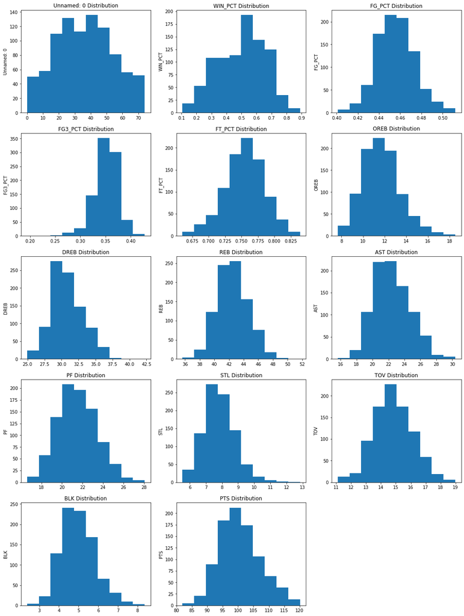

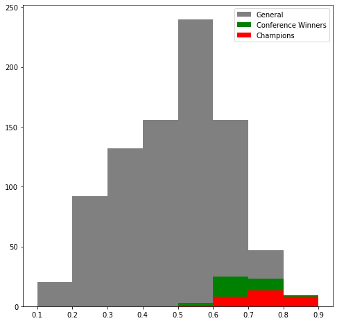

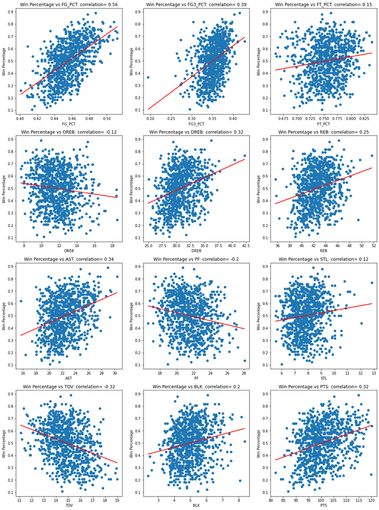

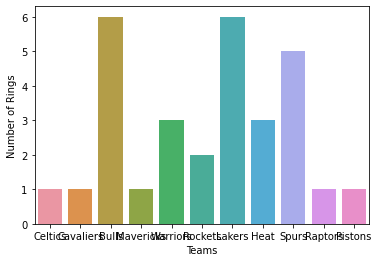

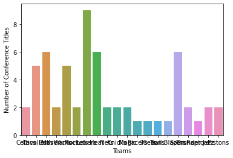

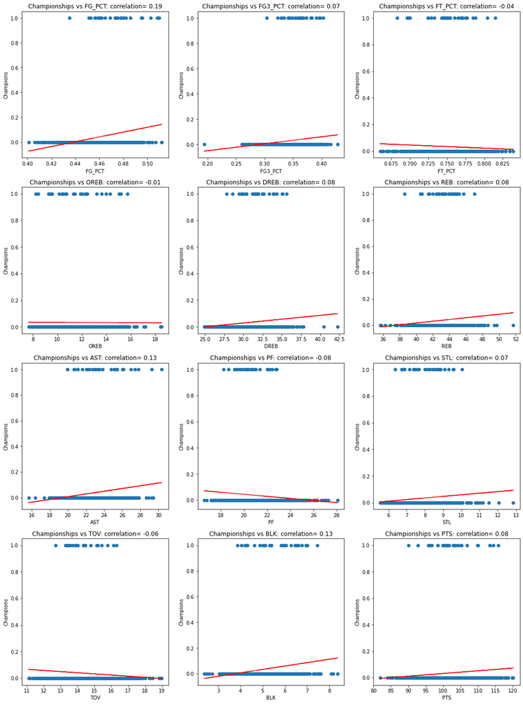

[figure not shown]

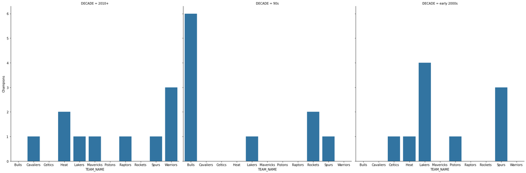

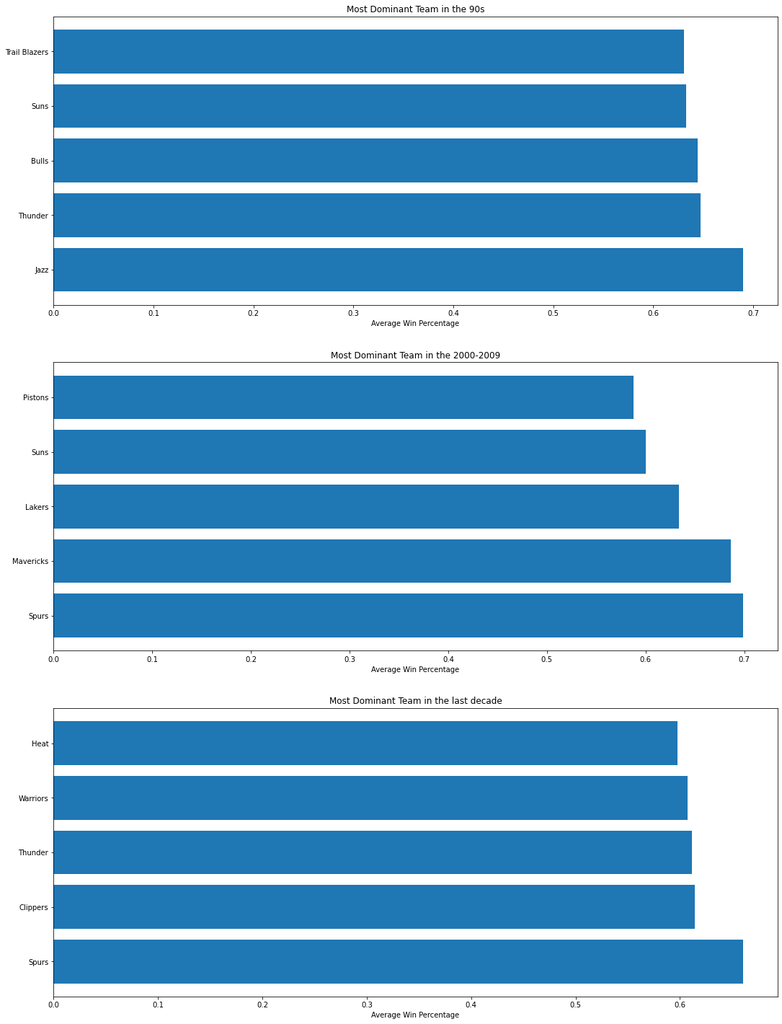

```python
import warnings
warnings.filterwarnings('ignore')
%run Data_Exploration.ipynb --clear output
```

## Which statistics are important and which statistics are not important when it comes to winning?

I will be measuring correlation through the Pearson's Correlation coefficient.

- Less than 0.2: weak correlation
- (0.2-0.4): moderate correlation
- 0.4+: strong correlation

```python
cols_to_eval = df.drop(columns=['WIN_PCT']).select_dtypes(float).columns
col_corr = [(x, np.round(pearsonr(df[x], df['WIN_PCT'])[0], 2) ) for x in cols_to_eval]
strong_corr = [(col, corr) for (col, corr) in col_corr if abs(corr) >= 0.4]
moderate_corr = [(col, corr) for (col, corr) in col_corr if (abs(corr) < 0.4 and abs(corr) >= 0.2)]
moderate_corr.sort(key=lambda tup: abs(tup[1]), reverse=True )
weak_corr = [(col, corr) for (col, corr) in col_corr if (abs(corr) < 0.2)]
moderate_corr.sort(key=lambda tup: abs(tup[1]), reverse=True )
```

```python
weak_corr, moderate_corr, strong_corr
```

```
([('FT_PCT', 0.15), ('OREB', -0.12), ('STL', 0.12)],
 [('FG3_PCT', 0.39),
  ('AST', 0.34),
  ('DREB', 0.32),
  ('TOV', -0.32),
  ('PTS', 0.32),
  ('REB', 0.25),
  ('PF', -0.2),
  ('BLK', 0.2)],
 [('FG_PCT', 0.56)])
```

**This is the only statistic with a strong correlation with win percentage (field goal percentage).**

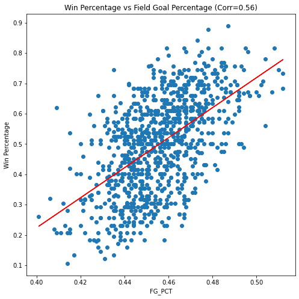

```python
col, corr = strong_corr[0]
plt.figure(figsize=(8, 8))
plt.scatter(data=df, x=col, y="WIN_PCT")
b, m = polyfit(df[col], df['WIN_PCT'], 1)
x = df[col]
plt.plot(x, b + m * x, '-', color='Red')
plt.ylabel('Win Percentage')
plt.xlabel(col)
plt.title("Win Percentage vs Field Goal Percentage (Corr=" + str(corr) + ')' );
```

**These are the statistics with moderate (0.2-0.4) correlation. As we can see 3-point field goal and assist can almost be considered strong correlation. Defensive Rebounds, Turnovers, and Points Scored have nice corrrelation above 0.3. Rebounds, Personal Fouls and Blocks also have moderate correlations.**

**NOTE: Personal Fouls and Turnovers had a negative correlation while all others had a positive one**

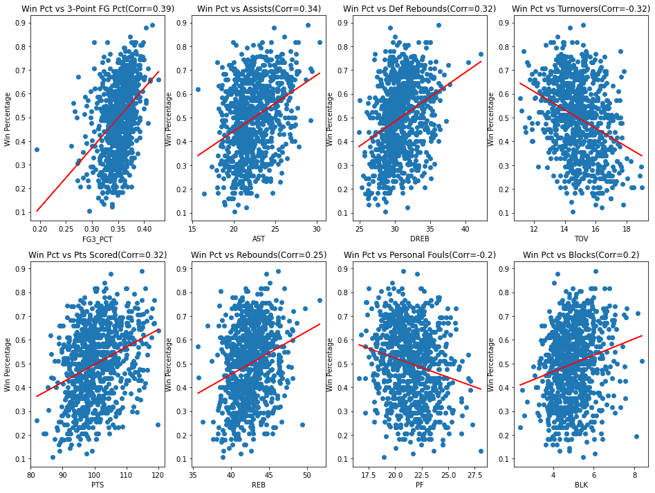

```python
fig = plt.figure(figsize=(16, 12))
titles = [
    '3-Point FG Pct',
    'Assists',
    'Def Rebounds',
    'Turnovers',
    'Pts Scored',
    'Rebounds',
    'Personal Fouls',
    'Blocks'
]

for i, (col, corr) in enumerate(moderate_corr) :
    ax = plt.subplot(2, 4, i+1);
    ax.scatter(data=df, x=col, y="WIN_PCT")
    b, m = polyfit(df[col], df['WIN_PCT'], 1)
    x = df[col]
    ax.plot(x, b + m * x, '-', color='Red')
    ax.set_ylabel('Win Percentage')
    ax.set_xlabel(col)
    correlation_ = str( np.round(pearsonr(x, df['WIN_PCT'])[0], 2) )
    ax.set_title("Win Pct vs " + titles[i] + '(Corr=' + correlation_ + ')')
```

**NOTE: Offensive Rebounds had a negative correlation while others didn't. This surprised me, but my theory is that teams have to miss shots to have a lot of high Offensive Rebounds. This can be tested but for the purpose of this presentation I did not do that.**

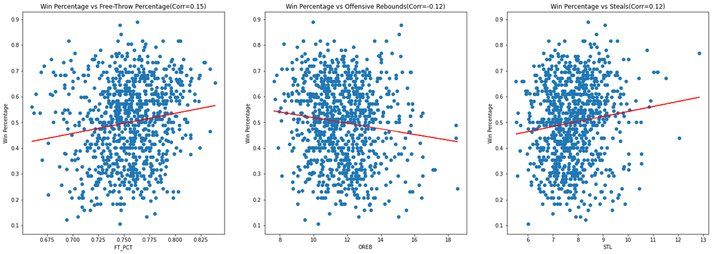

```python
fig = plt.figure(figsize=(24, 8))
titles = [
    'Free-Throw Percentage',
    'Offensive Rebounds',
    'Steals'
]

for i, (col, corr) in enumerate(weak_corr) :
    ax = plt.subplot(1, 3, i+1);
    ax.scatter(data=df, x=col, y="WIN_PCT")
    b, m = polyfit(df[col], df['WIN_PCT'], 1)
    x = df[col]
    ax.plot(x, b + m * x, '-', color='Red')
    ax.set_ylabel('Win Percentage')
    ax.set_xlabel(col)
    correlation_ = str( np.round(pearsonr(x, df['WIN_PCT'])[0], 2) )
    ax.set_title("Win Percentage vs " + titles[i] + '(Corr=' + correlation_ + ')')
```

## Which teams have NBA Finals appearances in the last 30 years and how many?

```python
teams_appearing = set( df[['TEAM_NAME', 'YEAR', 'NBA_FINALS_APPEARANCE']].dropna()['TEAM_NAME'] )
team_perf = df.query("TEAM_NAME in @teams_appearing")[['TEAM_NAME', 'Champions']].groupby("TEAM_NAME", as_index=False).sum()
_ = df.query("TEAM_NAME in @teams_appearing")[['TEAM_NAME', 'Conference Champions']].groupby("TEAM_NAME", as_index=False).sum()
team_perf['Conference Titles'] = _['Conference Champions']
team_perf.sort_values(by=['Champions', 'Conference Titles'], ascending=False, inplace=True)
```

**As we can see Lakers, Bulls and Spurs have the most rings with 6, 6 and 5 respectively. There are 17 other teams who have made a finals appearance atleast once (8 of which have atleast one ring).**

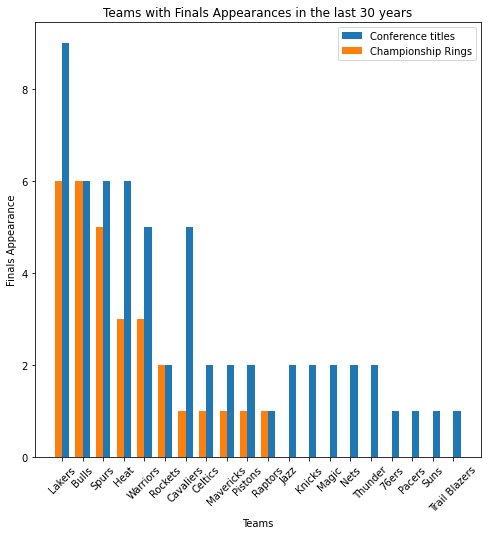

```python
fig = plt.figure(figsize=(8, 8))
n=len(team_perf)
r = np.arange(n)
width = 0.35

plt.bar(r+width, team_perf['Conference Titles'], label = 'Conference titles', width=width)
plt.bar(r, team_perf['Champions'], label = 'Championship Rings', width=width)

plt.xticks(r + width/2, team_perf['TEAM_NAME'], rotation = 45)
plt.legend()
plt.xlabel('Teams')
plt.ylabel('Finals Appearance')
plt.title('Teams with Finals Appearances in the last 30 years')

plt.show();
```

## Which teams have dominated each decade (win percentage and titles)?

```python
def sorter(column):
    """
    inputs:
        column (list of strings)
    return:
        pd.Series/pd.Categorical object that sorts the column
    """
    reorder = [
        "90s",
        "early 2000s",
        "2010+",
    ]
    temp = pd.Categorical(column, categories=reorder, ordered=True)
    return pd.Series(temp)

titles_by_decade = df[['TEAM_NAME', 'DECADE', 'Champions']].groupby(by=['DECADE', 'TEAM_NAME'], as_index=False).sum()
champ_teams = set(titles_by_decade.query("Champions != 0").TEAM_NAME)
titles_by_decade = titles_by_decade.query("TEAM_NAME in @champ_teams")

titles_by_decade.sort_values(by="DECADE", key=sorter, inplace=True)
```

**Here we see the teams that won titles in each of the 3 decades**

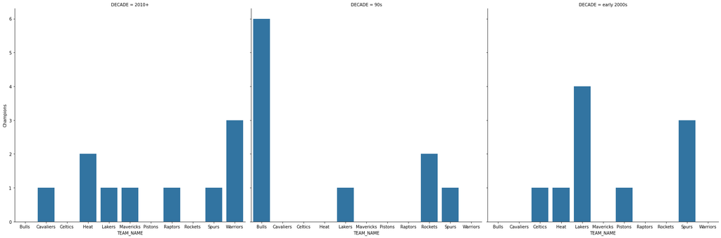

```python
titles_by_decade = df[['TEAM_NAME', 'DECADE', 'Champions']].groupby(by=['DECADE', 'TEAM_NAME'], as_index=False).sum()
champ_teams = set(titles_by_decade.query("Champions != 0").TEAM_NAME)
titles_by_decade = titles_by_decade.query("TEAM_NAME in @champ_teams")

g = sb.FacetGrid(data = titles_by_decade, col = 'DECADE', col_wrap = 3, size=8);
g.map(sb.barplot, 'TEAM_NAME', 'Champions');
```

```python
best_decade = df[['TEAM_NAME', 'DECADE', 'WIN_PCT']].groupby(by=['DECADE', 'TEAM_NAME'], as_index=False).mean(
    ).groupby(by='DECADE', as_index=False).apply(lambda x : x.sort_values(by = 'WIN_PCT', ascending = False).head(5).reset_index(drop = True))


best_decade.sort_values(by="DECADE", key=sorter, inplace=True)
```

**Here we see the top 5 teams (according to average win percentage) from each decade.**

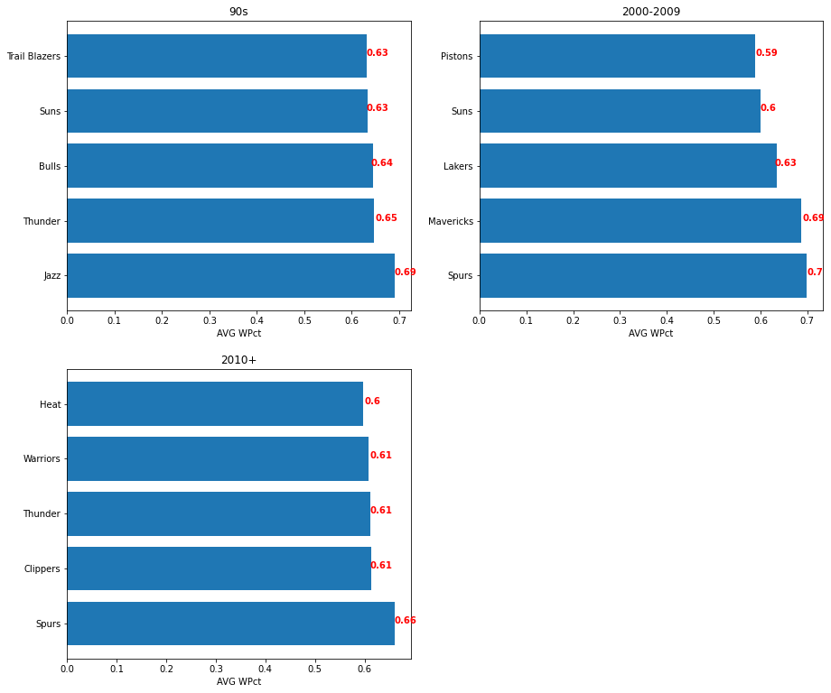

```python
def repeat_() :
    """
    No input or output
    -the objective of this function is to just draw the bar graph
    -df1 is changed every time we call repeat_
    -just eliminates code repitition
    """
    x, y = df1['TEAM_NAME'], df1['WIN_PCT']
    ax.barh(x, y)
    ax.set_xlabel('AVG WPct')
    for i, v in enumerate( round(df1['WIN_PCT'], 2) ):
        ax.text(v, i, str(v), color='red', fontweight='bold')



fig = plt.figure(figsize=(15, 13))
ax = plt.subplot(2, 2, 1)
df1 = best_decade.query("DECADE == '90s'")
ax.set_title('90s')
repeat_()

ax = plt.subplot(2, 2, 2)
df1 = best_decade.query("DECADE == 'early 2000s'")
ax.set_title('2000-2009')
repeat_()

ax = plt.subplot(2, 2, 3)
df1 = best_decade.query("DECADE == '2010+'")
ax.set_title('2010+')
repeat_()
```

## What are some of the surprise winners in the NBA Finals (underdogs who won the conference title or NBA Championship)?

As we can see some of the craziest NBA Champions were the **2005 Heat** with a low win percentage of *0.634*. Then we have the **1994 Rockets** who won the NBA title with a win record of *0.573*.

Some notable underdogs with low performing regular season records but conference titles, were:

- 1998 Knicks
- 2002 Nets
- 2019 Heat
- 2006 Cavaliers
- 2009 Celtics
- 2017 Cavaliers
- 2016 Cavaliers
- 2001 Nets
- 2014 Cavaliers

**Here we can see all the different underdogs by (season, team, win percentage) with the 2 NBA Champions at the top and then the 9 surprise conference winners.**

```python
#These are the 10 outliers
finals_df = df[['YEAR', 'TEAM_NAME', 'NBA_FINALS_APPEARANCE', 'WIN_PCT']].dropna().sort_values(['YEAR', 'NBA_FINALS_APPEARANCE'])
finals_df.query("WIN_PCT < 0.65").sort_values(['NBA_FINALS_APPEARANCE', 'WIN_PCT'], ascending=[False, True])
```

|  | YEAR | TEAM_NAME | NBA_FINALS_APPEARANCE | WIN_PCT |
| --- | --- | --- | --- | --- |
| 240 | 1994 | Rockets | LEAGUE CHAMPION | 0.573 |
| 344 | 2005 | Heat | LEAGUE CHAMPION | 0.634 |
| 461 | 1998 | Knicks | FINALS APPEARANCE | 0.540 |
| 434 | 2002 | Nets | FINALS APPEARANCE | 0.598 |
| 358 | 2019 | Heat | FINALS APPEARANCE | 0.603 |
| 78 | 2006 | Cavaliers | FINALS APPEARANCE | 0.610 |
| 50 | 2009 | Celtics | FINALS APPEARANCE | 0.610 |
| 89 | 2017 | Cavaliers | FINALS APPEARANCE | 0.610 |
| 88 | 2016 | Cavaliers | FINALS APPEARANCE | 0.622 |
| 433 | 2001 | Nets | FINALS APPEARANCE | 0.634 |
| 86 | 2014 | Cavaliers | FINALS APPEARANCE | 0.646 |

## Summary & Conclusion

  ```
    - 90s: Trail Blazers, Suns, Bulls, Thunder, and Jazz
    - early 2000s: Pistons, Suns, Lakers, Mavericks, and Spurs
    - last decade: Heat, Warrior, Thunders, Clippers and Spurs
  ```

- some surprising NBA finals winners were 2005 Heat and 1994 Rockets
- some surprise NBA Conference Winners were 1998 Knicks, 2002 Nets, 2019 Heat, 2009 Celtics, 2001 Nets and the Cavaliers (2006, 2014, 2016, and 2017)